# How Chemical Properties Of Red Wine Influence Quality

## Introduction to the Data Set

The red wine dataset that I chose contains 1,599 red wines with 12 variable related to the chemical properties of each wine. Three wine experts were responsible for rating the quality of each wine with a scale from 0 (terrible) up to 10 (exceptional).

## Univariate Plots Section

```
##        X          fixed.acidity   volatile.acidity  citric.acid
##  Min.   :   1.0   Min.   : 4.60   Min.   :0.1200   Min.   :0.000
##  1st Qu.: 400.5   1st Qu.: 7.10   1st Qu.:0.3900   1st Qu.:0.090
##  Median : 800.0   Median : 7.90   Median :0.5200   Median :0.260
##  Mean   : 800.0   Mean   : 8.32   Mean   :0.5278   Mean   :0.271
##  3rd Qu.:1199.5   3rd Qu.: 9.20   3rd Qu.:0.6400   3rd Qu.:0.420
##  Max.   :1599.0   Max.   :15.90   Max.   :1.5800   Max.   :1.000
##  residual.sugar     chlorides       free.sulfur.dioxide
##  Min.   : 0.900   Min.   :0.01200   Min.   : 1.00
##  1st Qu.: 1.900   1st Qu.:0.07000   1st Qu.: 7.00
##  Median : 2.200   Median :0.07900   Median :14.00
##  Mean   : 2.539   Mean   :0.08747   Mean   :15.87
##  3rd Qu.: 2.600   3rd Qu.:0.09000   3rd Qu.:21.00
##  Max.   :15.500   Max.   :0.61100   Max.   :72.00
##  total.sulfur.dioxide    density             pH          sulphates
##  Min.   :  6.00       Min.   :0.9901   Min.   :2.740   Min.   :0.3300
##  1st Qu.: 22.00       1st Qu.:0.9956   1st Qu.:3.210   1st Qu.:0.5500
##  Median : 38.00       Median :0.9968   Median :3.310   Median :0.6200
##  Mean   : 46.47       Mean   :0.9967   Mean   :3.311   Mean   :0.6581
##  3rd Qu.: 62.00       3rd Qu.:0.9978   3rd Qu.:3.400   3rd Qu.:0.7300
##  Max.   :289.00       Max.   :1.0037   Max.   :4.010   Max.   :2.0000
##     alcohol         quality
##  Min.   : 8.40   Min.   :3.000
##  1st Qu.: 9.50   1st Qu.:5.000
##  Median :10.20   Median :6.000
##  Mean   :10.42   Mean   :5.636
##  3rd Qu.:11.10   3rd Qu.:6.000
##  Max.   :14.90   Max.   :8.000
```

```
##  [1] "X"                    "fixed.acidity"        "volatile.acidity"
##  [4] "citric.acid"          "residual.sugar"       "chlorides"
##  [7] "free.sulfur.dioxide"  "total.sulfur.dioxide" "density"
## [10] "pH"                   "sulphates"            "alcohol"
## [13] "quality"
```

After taking an initial look at our data, I want to explore some of the counts of these variables such as alcohol, quality, and pH. I would like to look at the distributions to identify and possibly remove outliers from some of the variables so that we have a more accurate analysis.

## Distribution of All Variables

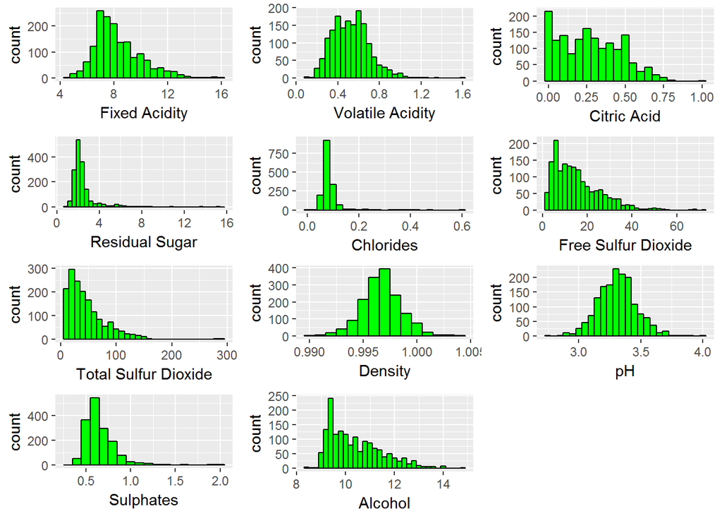

The variables which seem to have a normal distribution are **Volatile Acidity**, **pH**, and **Density**. The variables with a positively skewed distribution are **Fixed Acidity**, **Citric Acid**, **Free Sulfur Dioxide**, **Total Sulfur** **Dioxide**, and **Alcohol**. The variables that seem to have a long tail distribution are **Residual Sugar**, **Sulphates**, and **Chlorides**.

I would like to further inspect the three variables with long tail distributions to identify outliers.

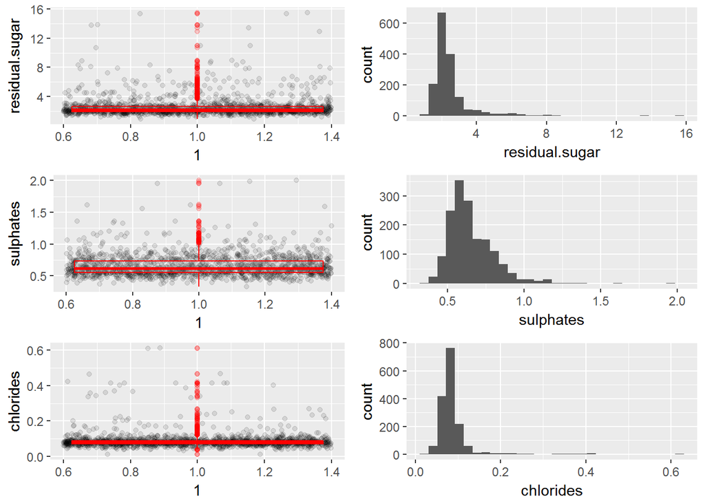

Here we can see the outliers at the upper end of each of these three variables. I am going to leave these outliers in the dataset, however it’s good to be aware that they are present when examining the plots utilizing these variables.

For the rest of the variables containing positively skewed distributions, I will try to do a log transformation on them to attempt to normalize their distribution.

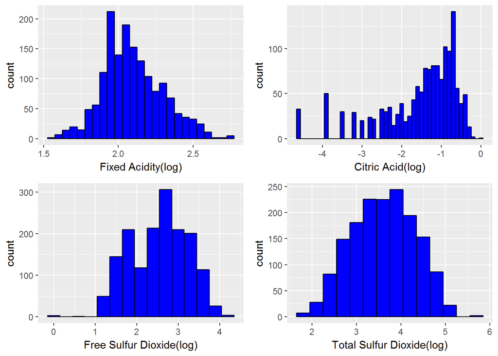

The distributions look a little more normalized with a log transformation applied. We will use these transformed variables in our bivariate and multivariate analysis. The citric acid variable has over 100 values showing “0”. I’m not sure if this is due to values not being available, or if those values are truly zero. I’m going to remove the log transformed citric acid variable and also remove the original variables columns for the characteristics with a successful log transformation.

```r
redwine$log.citric.acid <- NULL
redwine$fixed.acidity <- NULL
redwine$free.sulfur.dioxide <- NULL
redwine$total.sulfur.dioxide <- NULL
```

Let’s finally get a look at the quality variable.

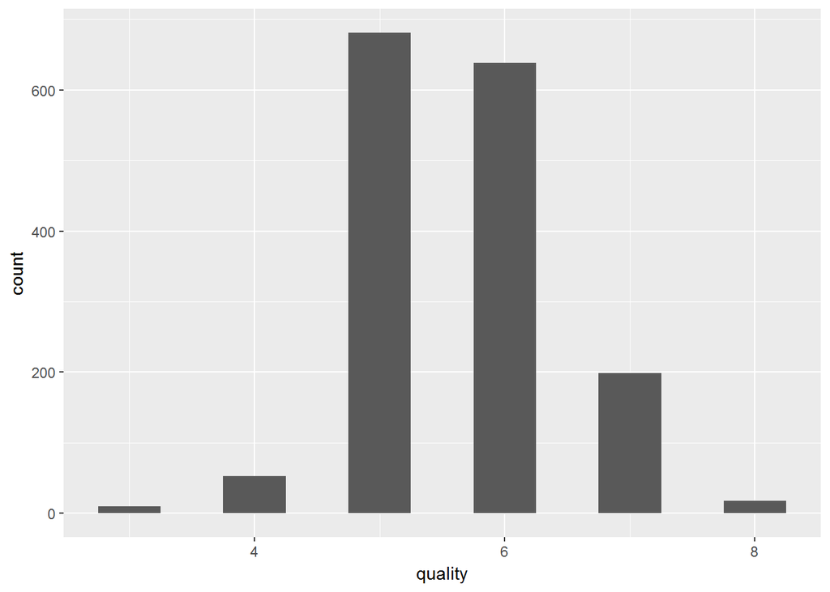

It appears that even though our reviews were able to scale from 1-10 based on quality, they kept the quality ratings between 3-8. It makes sense that the majority of red wine samples fall in the 5-6/average rating. I am going to create a new variable to put the ratings in buckets with 0-4 being “bad”, 5-6 being “average”, and 7-8 being “good”.

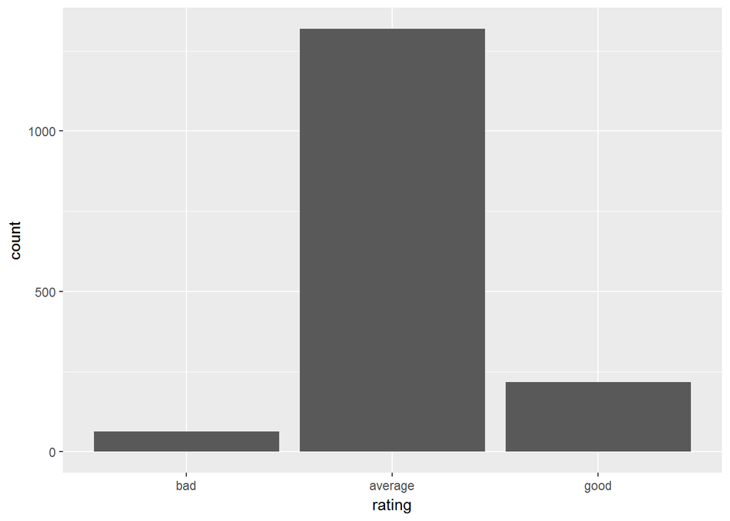

```r
redwine$rating <- ifelse(redwine$quality < 5, "bad",
                         ifelse(redwine$quality > 6, "good", "average"))

redwine$rating <- ordered(redwine$rating,
                     levels = c('bad', 'average', 'good'))

qplot(data = redwine, x = rating)
```

Here we can see that the majority, **over 1250**, of red wine samples were rated as average. Having such a large portion of our dataset rated as average red wine samples may make it harder for us to identify correlations between what qualities make a good wine, but we will try to focus on the good and bad rating.

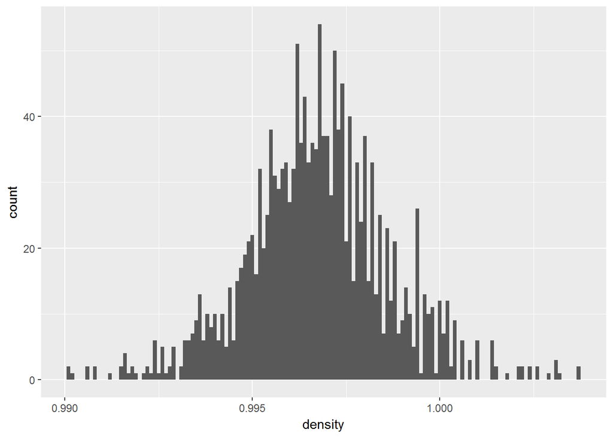

I wanted to get a closer look at the plot for the density variable. I’m curious to see how density and alchol are correlated. We will explore this further in the bivariate analysis.

## Univariate Analysis

### What is the structure of your dataset?

This dataset contains 1599 observations of red wine samples with 13 variables for each observation. All variables consist of numerical data, except for our quality variable which is categorical. I transformed the quality variable to only consist of three ratings, “bad”, “average”, and “good” to more easily identify patterns correlating with certain variables.

### What is/are the main feature(s) of interest in your dataset?

The main feature of interest in my dataset is the quality of the red wine sample.

### What other features in the dataset do you think will help support your investigation into your feature(s) of interest

I think the alcohol percentage, as well as the chemical composition of the alcohol, will both play a huge role in supporting the investigation into my feature of interest.

### Did you create any new variables from existing variables in the dataset?

I created a new variable from the quality data to give each wine a rating. Since most of the data was clustered around 5-6, I gave that an “average” rating. 0-4 I gave a “bad” rating and 7-10 I gave a “good” rating.

### Of the features you investigated, were there any unusual distributions? Did you perform any operations on the data to tidy, adjust, or change the form of the data? If so, why did you do this?

The red wine dataset was mostly tidy. I added an additional column to put the quality variable into buckets categorized by rating. I also transformed a few of the variables using a log transformation to try to normalize the distribution, as well as pointing out a few outliers with some of the variables in the red wine dataset.

## Bivariate Plots Section

Let’s first check the correlations of every variable matched up against each other to try to find out which ones have high/low correlations to each other.

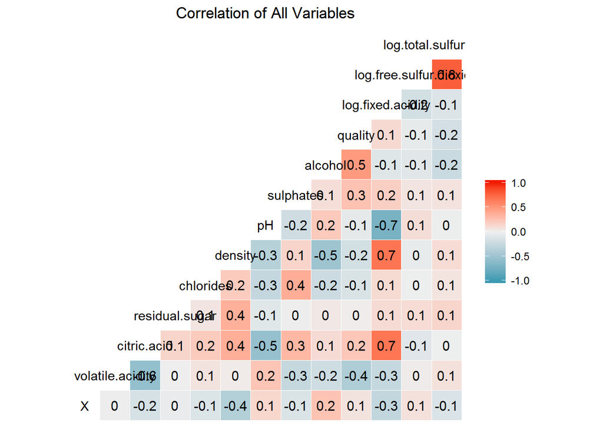

With this correlation matrix, we get a complete overview of variables and their positive or negative correlations. Right now I would like to focus on the variables that are correlated to quality.

#### Top 4 Correlations to Red Wine Quality

| Chemical Property | Correlation (Pearson) |
| --- | --- |
| Alcohol | 0.48 |
| Volatile Acidity | -0.39 |
| Sulphates | 0.25 |
| Citric Acid | 0.23 |

As expected, alcohol has the highest correlation with quality at 0.48. Volatile acidity has an inverse correlation with quality, and sulphates and citric acid have lower correlations with quality yet still a noticable amount. After a quick google search, it appears that volatile acidity has a huge impact on aroma and taste, explaining why it trails right behind alcohol regarding correlations to red wine quality.

Let’s plot alcohol against the rating variable I created to get a better look at the correlation between the two. I will just be using the bad and good rating to get a better picture of the correlation.

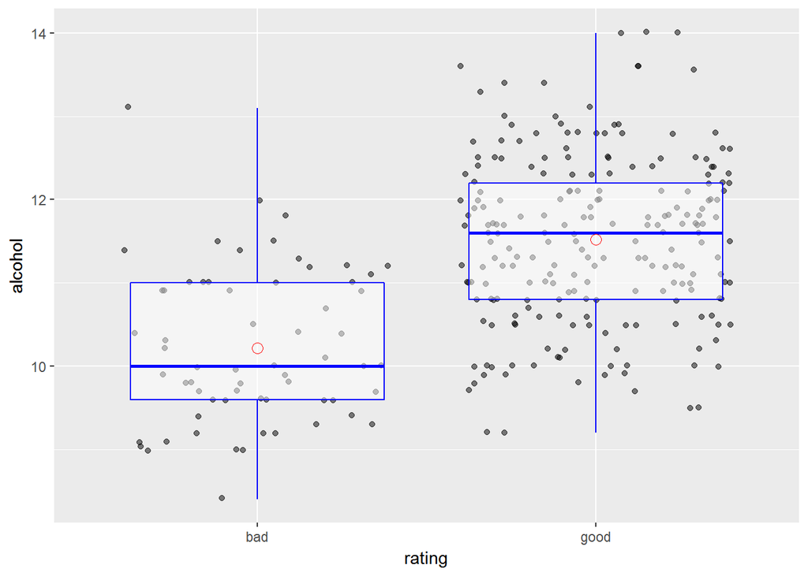

Here we show boxplots with the mean plotted for the red wine samples rated ‘bad’ and ‘good’. These box plots show the stark contrast between average alcohol content in a bad tasting red wine and a good tasting red wine.

Let’s take a look at ‘bad’ and ‘good’ rated red wines against the other top three correlated variables.

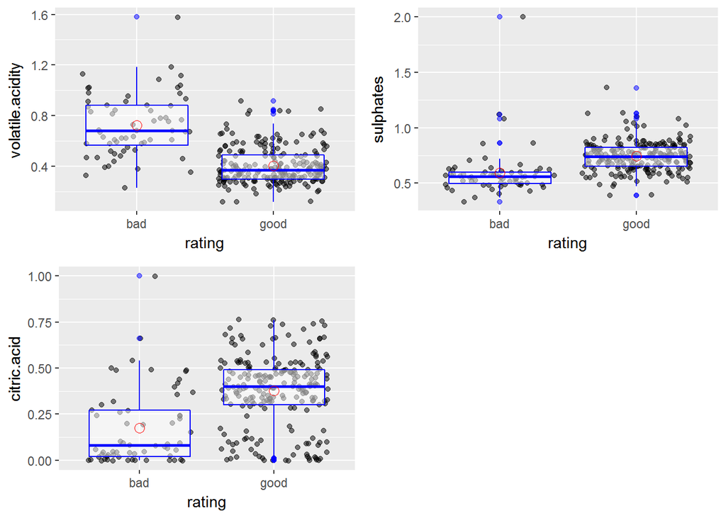

Our first boxplot shows the inverse relationship that volatile acidity has with wine quality. Next, we see that sulphates and citric acid have a positive correlation with our ‘good’ and ‘bad’ wine rating.

Now let’s take a quick look at the relationship between alcohol and density that we proposed earlier.

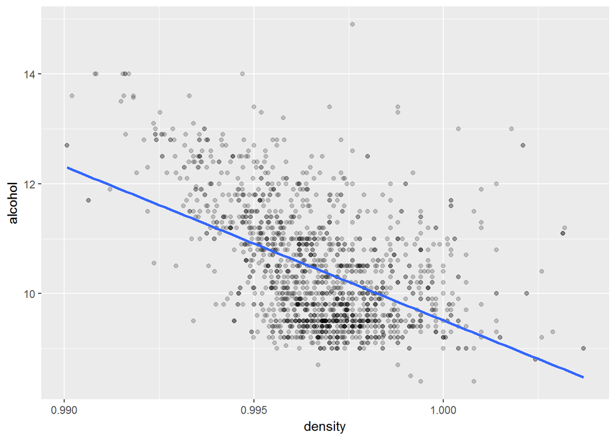

Here we can see the inverse correlation between alcohol and density. It almost seems intuitive that as the alcohol % decreases, the density increases. This is most likely due to alcohol having less density than water, or any other chemical components that make up our red wine dataset.

## Bivariate Analysis

### Talk about some of the relationships you observed in this part of the investigation. How did the feature(s) of interest vary with other features in the dataset?

It was interesting, yet not surprising, to see that alcohol had the highest positive correlation with quality/rating.

### Did you observe any interesting relationships between the other features (not the main feature(s) of interest)?

I found an inverse correlation with the quality of the red wine and the volatile acidity. This makes sense considering the documentation of the dataset noted that too high of a reading for volatile acidity will give the wine an unpleasant, vinegar taste.

### What was the strongest relationship you found?

The strongest relationship found so far was the relationship of alcohol content to the quality/rating from the judges.

## Multivariate Plots Section

Since I singled in on comparing the ‘bad’ and ‘good’ ratings in the bivariate analysis, I now want to include all the data for the red wines in my multivariate analysis. I will start by viewing the relationship between quality, volatile acidity, and alcohol content.

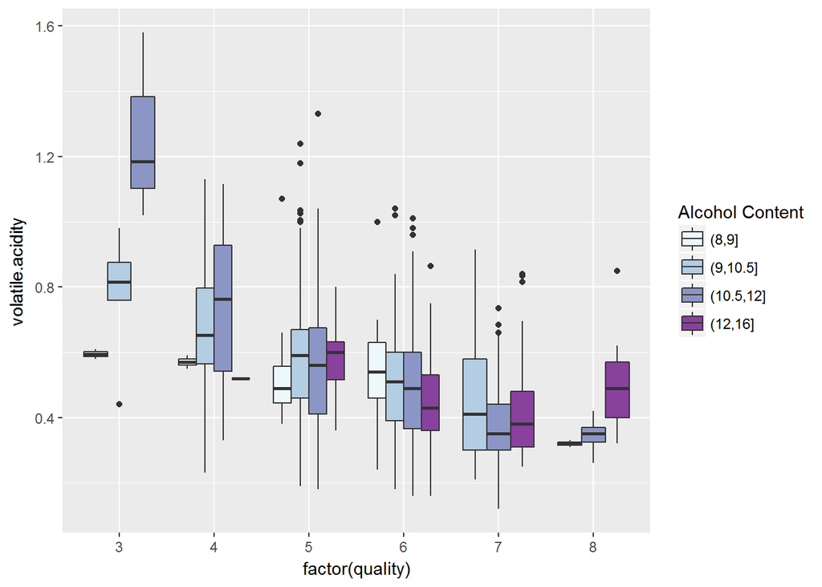

Adding in volatile acidity as a variable with alcohol shows the clear effect both have on the quality rating. We can easily see the inverse correlation between volatile acidity and quality. It seems that the sweet spot for a good tasting red wine is an alcohol content higher than 12% and a volatile acidity lower than 0.6 g/dm^3 .

I would like to take a look at the same visualization with sulphates instead of volatile acidity to see if the weaker correlation is still visual.

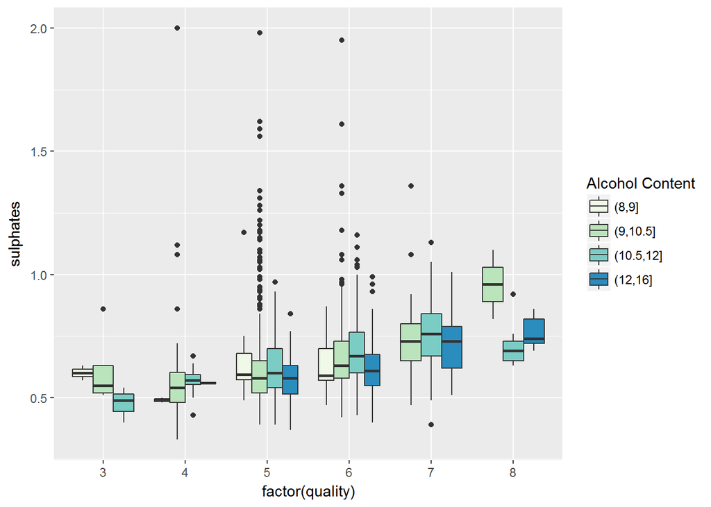

We can definitely notice the positive correlation between slightly higher sulphate levels and increase in quality. We can also see a lot of outliers with higher readings of sulphates.

Finally let’s view how density and alcohol relate to quality.

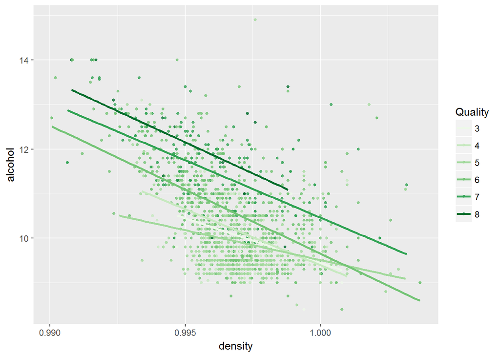

## Multivariate Analysis

### Talk about some of the relationships you observed in this part of the investigation. Were there features that strengthened each other in terms of looking at your feature(s) of interest?

Adding the two highest correlating variables of alcohol content and volatile acidity further reinforced their relationship to the quality of the red wine.

### Were there any interesting or surprising interactions between features?

It was interesting to find the relationship between alcohol content and density, as well as the relationship between the three variables with the highest correlation to quality.

## Final Plots and Summary

### Plot One

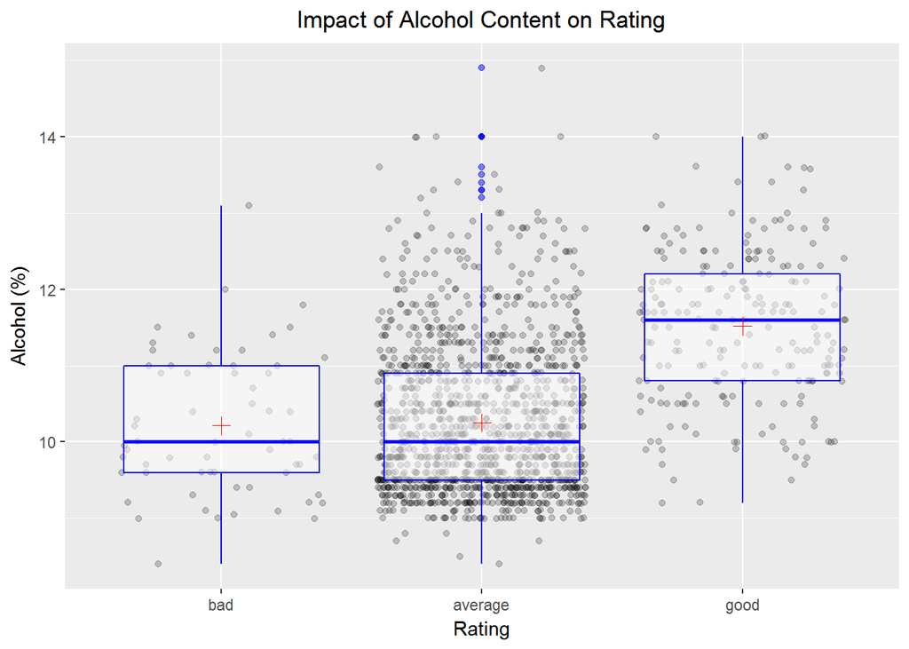

### Description One

This first plot introduces the huge correlation between alcohol content and the ‘rating’ categorical variable I created. In this final plot I show all three ratings of ‘bad’, ‘average’, and ‘good’ red wines. We can also see how our dataset favored data points that fell into the ‘average’ rating.

### Plot Two: Relationship of Alcohol and Density with Quality

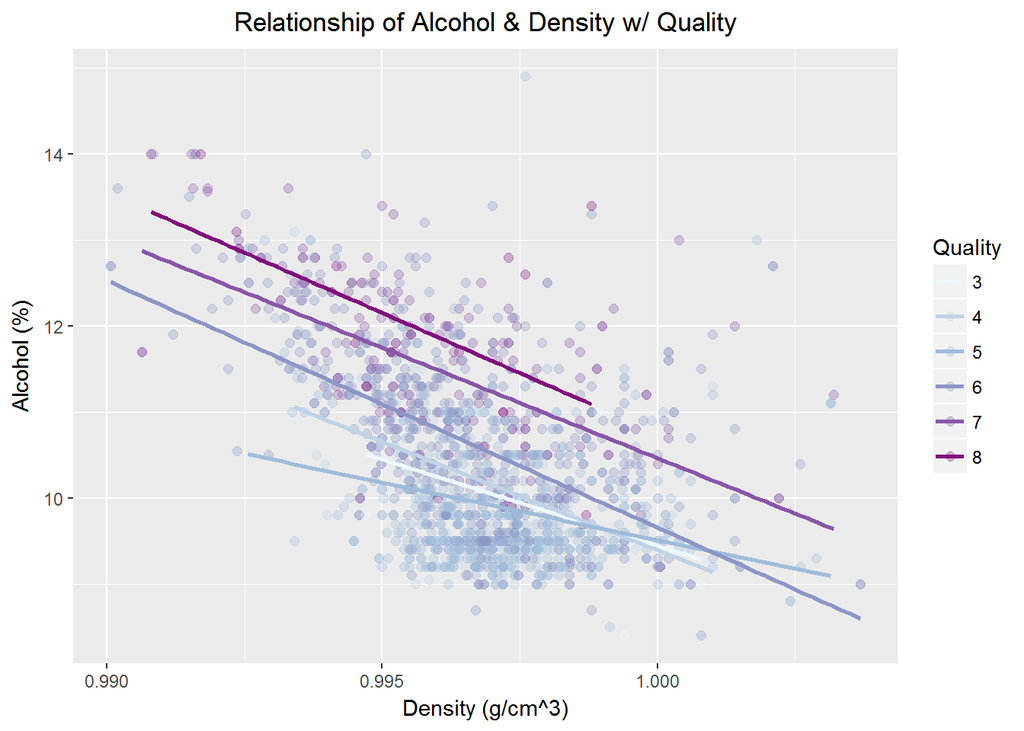

### Description Two

This second plot exemplifies the high correlation between density and alcohol content paired with how they both impact quality. This visualization shows that the sweet spot to be in is a lower density, which correlates to a higher alcohol content.

### Plot Three: Top Two Correlated Variables to Quality

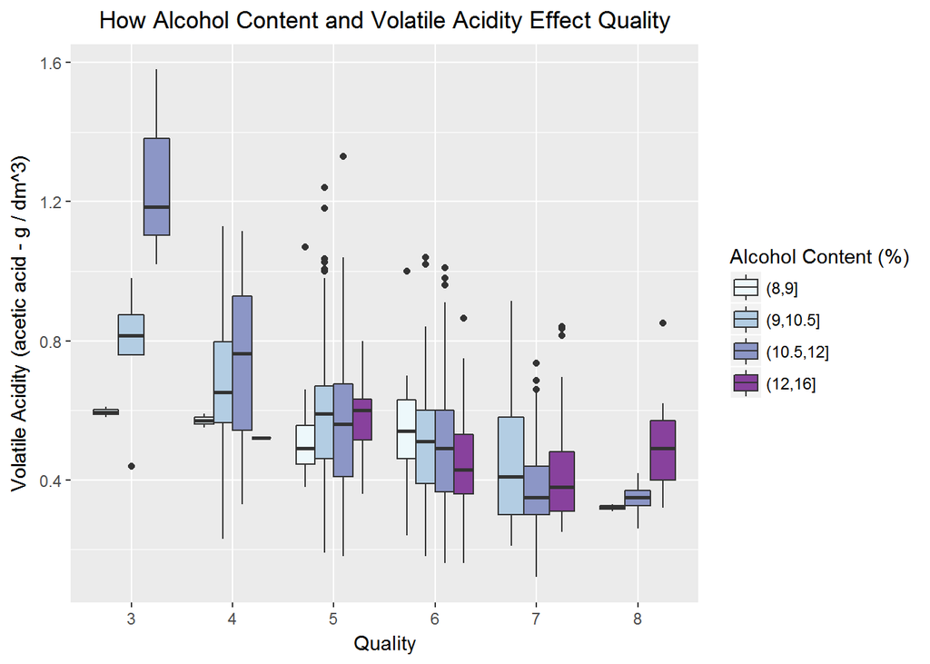

### Description Three

This plot may be the most important in our whole analysis. With this visualization, we are able to see how the two most highly correlated variables of alcohol and volatile acidity impact the quality of the red wine sample.

## Reflection

With this exploratory data analysis on the red wine dataset, I found that the biggest challenge was understanding the context of the variables I was analyzing. With a little help from Google, I was able to get a better understanding of what each variable was, and how they relate to the composition of each of the red wine samples.

My initial goal was to understand what variables were most important in determining the quality of red wine. The visuals and stats I ran on the dataset started giving me insight into a number of correlations between variables. The largest correlation I found in relation to the quality of red wine was the alcohol content. I found that the red wines with a higher rating generally had a higher alcohol content, and the lower quality wines consisted of a lower alcohol content. This correlation does not necessarily mean that every red wine with a high alcohol content tastes good. I believe it’s all about finding a sweet spot, no pun intended, when fermenting a good red wine. Another surprising correlation was that of citric acid and volatile acidity, which had a large inverse relationship.

In the future, running an analysis with the same variables but for different types of wine could be beneficial into gaining insight into exactly what makes the perfect wine. It could maybe also shed some light that there are certain chemical properties and factors which determine a good tasting wine depending on what variety of wine you are fermenting and processing. This project gave me a greater appreciation for always asking questions and exploring the data to try to find answers.